# Homework 1: workflow and graphics practice

Kanyarat Suwannama  
2022-01-25

In our discussion of the Citi Bike case study, we started considering the effect of the pandemic on ridership and rebalancing, and how we might find some insight by looking at data related to other transportation systems in the city. In this homework, we will continue *exploratory data analysis* for this case study as *prerequisites* for communicating with particular audiences for particular purposes.

**Opportunity alert**: In this assignment, I provide most of the code and you fill in the blank (using functions introduced in our class slides and demonstration code) to get it working. But understand what I’ve coded to help you code on your own in future work.

# Preliminary setup

If you have not already, install the `tidyverse` and `distill` R packages.

Create a directory on your computer for your homework. Place this file in that directory. In RStudio, create a **project** in that same directory. Now, when you import the data you will only need to specify the subdirectory as part of your name. This preparatory step helps your work be **reproducible**.

For this assignment, import data on New York City ridership from https://new.mta.info/coronavirus/ridership. You’ll need to open the website, then click “Download all the data”, which will be the `csv` file you’ll use for this homework. Create a subdirectory called `data` and place the `csv` file you downloaded into it. Name the file `MTA_recent_ridership_data.csv`.

Load the `tidyverse` library package (which includes `dplyr` and `ggplot2` functions) inside the code chunk below:

```r
library(tidyverse)
```

# Question 1: importing and summarising

Import the data into a data frame named `d` and show a summary (hint, in your console, after you load the tidyverse library, you can type ? before `read_csv` or `glimpse` to learn more about functions for this purpose):

Use the two functions below to import and summarize your data variables:

```r
# enter code to import and summarize your data frame variables here.

d <- read_csv("MTA_recent_ridership_data.csv")
glimpse(d)
```

```
Rows: 689
Columns: 13
$ Date                                                             <chr> …
$ `Subways: Total Estimated Ridership`                             <dbl> …
$ `Subways: % of Comparable Pre-Pandemic Day`                      <chr> …
$ `Buses: Total Estimated Ridership`                               <dbl> …
$ `Buses: % of Comparable Pre-Pandemic Day`                        <chr> …
$ `LIRR: Total Estimated Ridership`                                <dbl> …
$ `LIRR: % of 2019 Monthly Weekday/Saturday/Sunday Average`        <chr> …
$ `Metro-North: Total Estimated Ridership`                         <chr> …
$ `Metro-North: % of 2019 Monthly Weekday/Saturday/Sunday Average` <chr> …
$ `Access-A-Ride: Total Scheduled Trips`                           <chr> …
$ `Access-A-Ride: % of Comprable Pre-Pandemic Day`                 <chr> …
$ `Bridges and Tunnels: Total Traffic`                             <dbl> …
$ `Bridges and Tunnels: % of Comparable Pre-Pandemic Day`          <chr> …
```

# Question 2: tidying

The column or variable names will be difficult to work with as they are currently written. First, we will rename variables so the data frame will be easier to work with in code:

```r
new_names <-
  paste(
    rep(c('subway', 'bus', 'lirr',
          'mta', 'access_ride', 'bridge_tunnel'),
        each = 2),
    rep(c("total", "change"),
        times = 6),
    sep = '_'
    )

colnames(d) <- c('date', new_names)
```

Also, notice some of the variables are of the wrong type. The variable `Date`, for example, is an array of type `char`. Let’s change this to a proper `date` type. And all the variables with a percentage are also of a type `char`. Finally, the now renamed variable `mta_total` is of type char.

Below, explain why variable `mta_total` is of type `char`:

# Question 3: more tidying

Next, we’ll clean the variables holding percentages as a type `char`. We’ll do this by removing the `%` and recasting the variables, all in one set of piping functions:

```r
d <- d %>%
  mutate( date = as.Date(date, format = '%m/%d/%Y') ) %>%
  mutate( mta_total = as.numeric(mta_total) ) %>%
  mutate_if( is.character, str_replace_all, pattern = '%', replacement = '' ) %>%
  mutate_if( is.character, as.numeric )
```

In R, missing data is represented as `NA`. Does your data frame `d` have any missing data? If so, where?

```r
sum(is.na(d))
```

```
[1] 130
```

# Question 4: transforming

This dataset was used to visualize several graphics in the New York Times, in the article we reviewed in class: Penney, Veronica. *How Coronavirus Has Changed New York City Transit, in One Chart*. New York Times, March 8, 2021. https://www.nytimes.com/interactive/2021/03/08/climate/nyc-transit-covid.html.

The first graphic maps a three-day rolling average of the change in ridership since the lockdown in New York on March 22 for several of the transportation types {`bridge and tunnel traffic`, `Buses`, `Subways`, `LIRR`, `Metro-North`}. Let’s see how much the three day rolling average *affects the decoding* of this graphic compared with our non-averaged values.

The best way to encode the raw change for each transportation type requires we transform our data frame from *wide* to *long* format.

More specifically, the data frame currently includes each transportation type as a different variable. Instead, we want to have one variable we will call `transportation_type` and each observation will include the type and the remaining information.

Thus, our goal is to make our data frame look something like this:

| date | transportation_type | change |
| --- | --- | --- |
| 2021-09-16 | subway | -57.6 |
| 2021-09-16 | bus | -57.1 |
| 2021-09-16 | lirr | -56 |
| … | … | … |

To do that, we will use the function `pivot_longer`. Review the help file for this function. Now, we need to specify which columns to pivot, and what names to give them. Complete the code below:

```r
d <- d %>%
  select( contains(c('date', 'change')) ) %>%
  rename_with(~ gsub('_change', '', .x) )
```

```r
d <- d %>%
pivot_longer(cols = c("subway", "bus", "lirr", "mta", "access_ride","bridge_tunnel"),
             names_to = "transportation_type",
             values_to = "change")
d[,3] = -d[,3]
```

# Question 5: visualizing

Now that we have our data frame `d` in long format, we can create our visual. For this visual, we want to only graph the transportation types shown in the NYT article: `bridge_tunnel`, `bus`, `lirr`, `mta`, and `subway`. The easiest way to create the graphic will be to filter the other transportation types from the data frame, and graph with the `ggplot` function and the `geom_line`. I’ve written some code to get you started that you’ll need to complete:

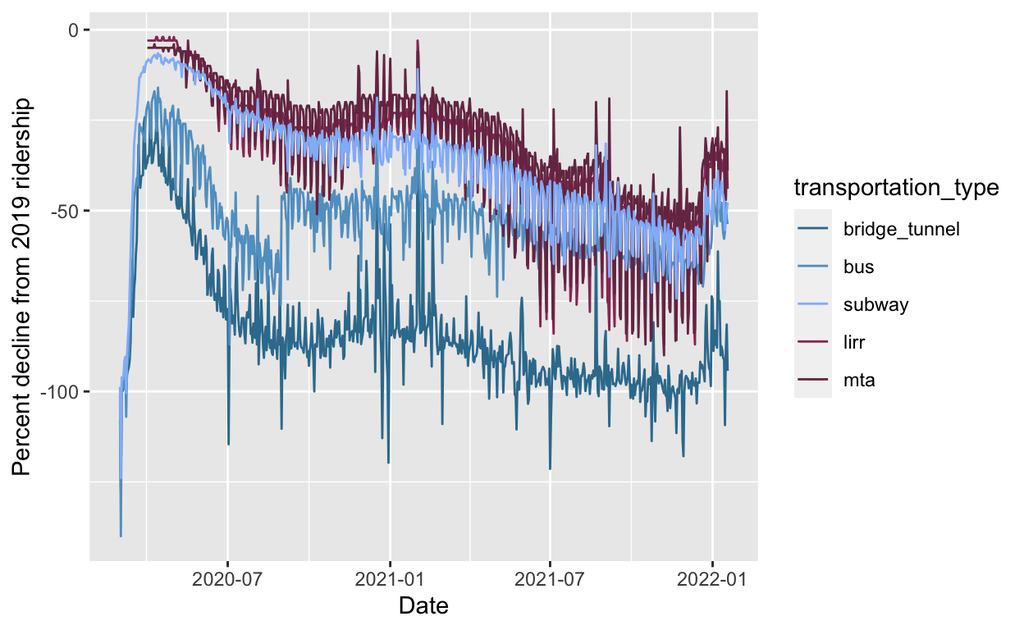

```r
d %>%
  filter(

    d$transportation_type != "access_ride"

  ) %>%

  ggplot(aes(x=date, y=change, group=transportation_type)) +

  scale_color_manual(
    breaks = c('bridge_tunnel', 'bus', 'subway', 'lirr', 'mta'),
    values = c('#367C9D', '#61A0CA', '#91BBF9', '#993865', '#773452')
  ) +

  labs(
    x = 'Date',
    y = 'Percent decline from 2019 ridership'
  ) +

  geom_line(aes(color = transportation_type))
```

# Question 6: communication — basic insights

Which version of the data encodings would a mixed audience of Citi Bike executives find easier to read (decode) — our version that encodes the actual daily changes for each transportation type *or* the NYT version that uses a three day rolling average — and why?

> I think the executives will find NYT version to decode that uses a three day rolling average because the graph is already represented the trend lines of a sharp decline in ridership and revenue of each transportation types. In contrast, our version graph was flunctuated and volatite as the graph was derived from raw data of avarage day-to-day, and this may be hard to intreprete and confusion. Also, the graph label of NYT graph is easier to read and more tidy as X-axis written in month and while our version graph is written as integer Year-Month, which is adding too much number in a single graph.

# Question 7: communication — questions needing more exploration

The NYT article did not include changes in ridership for the Citi Bike bike share. If we graphed the changes in Citi Bike bike rides alongside the transportation types we just graphed, how do you think the changes Citi Bike rides would compare with these other transportation types and why? Explain to a Citi Bike analytics executive.

> New York City’s drop in public transit riders to the shift to remote work and a faill in tourism caused a substantial decline in demand of all transportation types including Citi Bike usage during the initial lockdown. However, the pandamic makes more people rely on bike-sharing as a one relatively safe way to travel and social distance from other people. According to New York Times (Barron, 2021), it is mentioned that some riders in busy neighborhoods complain docking stations that are full, making it difficult to return bikes and others find empty stations when they need a bike. Moreover, bike shares and bike sales are experiencing a boom in the city (Penney, 2021) and more flexible remote options could help reduce transit emissions. With these impilications, the change of Citi Bike ridership may rise back faster to its post-pandemic normal comparing to other transportation types.

# Question 8: Preparing a reproducible communication

In submitting this **individual** assignment, you are representing your answers are your own. Properly **Cite** all resources used in completing this assignment.

Anon, 2020. Read CSV in R 📁 (import CSV files in R) [with several examples]. R CODER. Available at: https://r-coder.com/read-csv-r/#:~:text=In%20order%20to%20load%20a,frame%20.&text=If%20you%20just%20execute%20the,assigned%20it%20to%20any%20variable. [Accessed January 24, 2022]. Barron, J., 2021. Can we pedal any faster? The New York Times. Available at: https://www.nytimes.com/2021/12/03/nyregion/can-we-pedal-any-faster.html [Accessed January 24, 2022]. Keshner, A., 2021. There’s a covid-related bicycle shortage in the U.S. MarketWatch. Available at: https://www.marketwatch.com/story/why-is-there-a-bicycle-shortage-its-got-a-lot-to-do-with-why-fireworks-are-scarce-11622751152 [Accessed January 24, 2022]. Penney, V., 2021. How coronavirus has changed New York City Transit, in one chart. The New York Times. Available at: https://www.nytimes.com/interactive/2021/03/08/climate/nyc-transit-covid.html [Accessed January 24, 2022].

**Knit** your answers in this r markdown file into an `html` file. Submit into courseworks both files (the `lastname-firstname-hw1.rmd` and the knitted `lastname-firstname-hw1.html`). We should be able to reproduce your `html` file just by opening your `rmd` file and knitting.